# Cab EDA

Andrade

7/16/2020

```r
library(tidyverse)
library(dplyr)
library(lubridate)
```

```r
library(ggplot2)
library(scales)
library(ggpubr)
```

Cleaning the data and obtaining a Sample from the Data Set:

First we filter the data using trip distance as it is a very good indicator of possible mistakes or any extreme outliers that are not representative of the general populace. The data will be limited to New York State (NYS). NYS is 330 miles long and 285 miles wide at its longest and widest points respectively. Therefore, the minimum trip distance will be set to 0.50 miles and maximum at 300 miles, as a trip of over 300 miles is most certainly outside of NYS. We will also omit all NA values and all negative values.

Second we calculate a sample size. Using online sample size calculators such as SurveyMonkey we are able to obtain a sample size which is representative of our population for easier data manipulation. The Margin of Error is set at 1%, which is the range which your population may deviate from the sample, and Confidence Level at 95%, which is the probability that your sample accurately reflects your population. Most of these sample sizes come between 7900 and 9600, So we will use 10000 as the sample size for a cleaner data manipulation.

https://www.surveymonkey.com/mp/sample-size-calculator/

Repeat cleaning and filtering for every month. The data cleaning and filtering is done in chunks as to make the code cleaner and the memory management easier.

```r
yellowData01 <- read.csv("yellow_tripdata_2019-01.csv")
yellowData01 <- yellowData01%>%na.omit()
yellowData01 <- filter(yellowData01, VendorID <= 2, passenger_count >= 1, trip_distance >= 0.50, trip_distance <= 300.0, RatecodeID >= 1 & RatecodeID <= 6, fare_amount >= 0, extra >= 0, mta_tax >= 0, tip_amount >= 0, tolls_amount >= 0, improvement_surcharge >= 0, total_amount >= 0, congestion_surcharge >= 0)
yellowData01 <- yellowData01[sample(nrow(yellowData01), 10000),]


greenData01 <- read.csv("green_tripdata_2019-01.csv")
greenData01 <- greenData01[-15]
greenData01 <- greenData01%>%na.omit()
greenData01 <- filter(greenData01, VendorID <= 2, passenger_count >= 1, trip_distance >= 0.50, trip_distance <= 300.0, RatecodeID >= 1 & RatecodeID <= 6, fare_amount >= 0, extra >= 0, mta_tax >= 0, tip_amount >= 0, tolls_amount >= 0, improvement_surcharge >= 0, total_amount >= 0, congestion_surcharge >= 0)
greenData01 <- greenData01[sample(nrow(greenData01), 10000),]
```

```r
yellowData02 <- read.csv("yellow_tripdata_2019-02.csv")
yellowData02 <- yellowData02%>%na.omit()
yellowData02 <- filter(yellowData02, VendorID <= 2, passenger_count >= 1, trip_distance >= 0.50, trip_distance <= 300.0, RatecodeID >= 1 & RatecodeID <= 6, fare_amount >= 0, extra >= 0, mta_tax >= 0, tip_amount >= 0, tolls_amount >= 0, improvement_surcharge >= 0, total_amount >= 0, congestion_surcharge >= 0)
yellowData02 <- yellowData02[sample(nrow(yellowData02), 10000),]


greenData02 <- read.csv("green_tripdata_2019-02.csv")
greenData02 <- greenData02[-15]
greenData02 <- greenData02%>%na.omit()
greenData02 <- filter(greenData02, VendorID <= 2, passenger_count >= 1, trip_distance >= 0.50, trip_distance <= 300.0, RatecodeID >= 1 & RatecodeID <= 6, fare_amount >= 0, extra >= 0, mta_tax >= 0, tip_amount >= 0, tolls_amount >= 0, improvement_surcharge >= 0, total_amount >= 0, congestion_surcharge >= 0)
greenData02 <- greenData02[sample(nrow(greenData02), 10000),]
```

```r
yellowData03 <- read.csv("yellow_tripdata_2019-03.csv")
yellowData03 <- yellowData03%>%na.omit()
yellowData03 <- filter(yellowData03, VendorID <= 2, passenger_count >= 1, trip_distance >= 0.50, trip_distance <= 300.0, RatecodeID >= 1 & RatecodeID <= 6, fare_amount >= 0, extra >= 0, mta_tax >= 0, tip_amount >= 0, tolls_amount >= 0, improvement_surcharge >= 0, total_amount >= 0, congestion_surcharge >= 0)
yellowData03 <- yellowData03[sample(nrow(yellowData03), 10000),]


greenData03 <- read.csv("green_tripdata_2019-03.csv")
greenData03 <- greenData03[-15]
greenData03 <- greenData03%>%na.omit()
greenData03 <- filter(greenData03, VendorID <= 2, passenger_count >= 1, trip_distance >= 0.50, trip_distance <= 300.0, RatecodeID >= 1 & RatecodeID <= 6, fare_amount >= 0, extra >= 0, mta_tax >= 0, tip_amount >= 0, tolls_amount >= 0, improvement_surcharge >= 0, total_amount >= 0, congestion_surcharge >= 0)
greenData03 <- greenData03[sample(nrow(greenData03), 10000),]
```

```r
yellowData04 <- read.csv("yellow_tripdata_2019-04.csv")
yellowData04 <- yellowData04%>%na.omit()
yellowData04 <- filter(yellowData04, VendorID <= 2, passenger_count >= 1, trip_distance >= 0.50, trip_distance <= 300.0, RatecodeID >= 1 & RatecodeID <= 6, fare_amount >= 0, extra >= 0, mta_tax >= 0, tip_amount >= 0, tolls_amount >= 0, improvement_surcharge >= 0, total_amount >= 0, congestion_surcharge >= 0)
yellowData04 <- yellowData04[sample(nrow(yellowData04), 10000),]


greenData04 <- read.csv("green_tripdata_2019-04.csv")
greenData04 <- greenData04[-15]
greenData04 <- greenData04%>%na.omit()
greenData04 <- filter(greenData04, VendorID <= 2, passenger_count >= 1, trip_distance >= 0.50, trip_distance <= 300.0, RatecodeID >= 1 & RatecodeID <= 6, fare_amount >= 0, extra >= 0, mta_tax >= 0, tip_amount >= 0, tolls_amount >= 0, improvement_surcharge >= 0, total_amount >= 0, congestion_surcharge >= 0)
greenData04 <- greenData04[sample(nrow(greenData04), 10000),]
```

```r
yellowData05 <- read.csv("yellow_tripdata_2019-05.csv")
yellowData05 <- yellowData05%>%na.omit()
yellowData05 <- filter(yellowData05, VendorID <= 2, passenger_count >= 1, trip_distance >= 0.50, trip_distance <= 300.0, RatecodeID >= 1 & RatecodeID <= 6, fare_amount >= 0, extra >= 0, mta_tax >= 0, tip_amount >= 0, tolls_amount >= 0, improvement_surcharge >= 0, total_amount >= 0, congestion_surcharge >= 0)
yellowData05 <- yellowData05[sample(nrow(yellowData05), 10000),]


greenData05 <- read.csv("green_tripdata_2019-05.csv")
greenData05 <- greenData05[-15]
greenData05 <- greenData05%>%na.omit()
greenData05 <- filter(greenData05, VendorID <= 2, passenger_count >= 1, trip_distance >= 0.50, trip_distance <= 300.0, RatecodeID >= 1 & RatecodeID <= 6, fare_amount >= 0, extra >= 0, mta_tax >= 0, tip_amount >= 0, tolls_amount >= 0, improvement_surcharge >= 0, total_amount >= 0, congestion_surcharge >= 0)
greenData05 <- greenData05[sample(nrow(greenData05), 10000),]
```

```r
yellowData06 <- read.csv("yellow_tripdata_2019-06.csv")
yellowData06 <- yellowData06%>%na.omit()
yellowData06 <- filter(yellowData06, VendorID <= 2, passenger_count >= 1, trip_distance >= 0.50, trip_distance <= 300.0, RatecodeID >= 1 & RatecodeID <= 6, fare_amount >= 0, extra >= 0, mta_tax >= 0, tip_amount >= 0, tolls_amount >= 0, improvement_surcharge >= 0, total_amount >= 0, congestion_surcharge >= 0)
yellowData06 <- yellowData06[sample(nrow(yellowData06), 10000),]


greenData06 <- read.csv("green_tripdata_2019-06.csv")
greenData06 <- greenData06[-15]
greenData06 <- greenData06%>%na.omit()
greenData06 <- filter(greenData06, VendorID <= 2, passenger_count >= 1, trip_distance >= 0.50, trip_distance <= 300.0, RatecodeID >= 1 & RatecodeID <= 6, fare_amount >= 0, extra >= 0, mta_tax >= 0, tip_amount >= 0, tolls_amount >= 0, improvement_surcharge >= 0, total_amount >= 0, congestion_surcharge >= 0)
greenData06 <- greenData06[sample(nrow(greenData06), 10000),]
```

```r
yellowData07 <- read.csv("yellow_tripdata_2019-07.csv")
yellowData07 <- yellowData07%>%na.omit()
yellowData07 <- filter(yellowData07, VendorID <= 2, passenger_count >= 1, trip_distance >= 0.50, trip_distance <= 300.0, RatecodeID >= 1 & RatecodeID <= 6, fare_amount >= 0, extra >= 0, mta_tax >= 0, tip_amount >= 0, tolls_amount >= 0, improvement_surcharge >= 0, total_amount >= 0, congestion_surcharge >= 0)
yellowData07 <- yellowData07[sample(nrow(yellowData07), 10000),]


greenData07 <- read.csv("green_tripdata_2019-07.csv")
greenData07 <- greenData07[-15]
greenData07 <- greenData07%>%na.omit()
greenData07 <- filter(greenData07, VendorID <= 2, passenger_count >= 1, trip_distance >= 0.50, trip_distance <= 300.0, RatecodeID >= 1 & RatecodeID <= 6, fare_amount >= 0, extra >= 0, mta_tax >= 0, tip_amount >= 0, tolls_amount >= 0, improvement_surcharge >= 0, total_amount >= 0, congestion_surcharge >= 0)
greenData07 <- greenData07[sample(nrow(greenData07), 10000),]
```

```r
yellowData08 <- read.csv("yellow_tripdata_2019-08.csv")
yellowData08 <- yellowData08%>%na.omit()
yellowData08 <- filter(yellowData08, VendorID <= 2, passenger_count >= 1, trip_distance >= 0.50, trip_distance <= 300.0, RatecodeID >= 1 & RatecodeID <= 6, fare_amount >= 0, extra >= 0, mta_tax >= 0, tip_amount >= 0, tolls_amount >= 0, improvement_surcharge >= 0, total_amount >= 0, congestion_surcharge >= 0)
yellowData08 <- yellowData08[sample(nrow(yellowData08), 10000),]

greenData08 <- read.csv("green_tripdata_2019-08.csv")
greenData08 <- greenData08[-15]
greenData08 <- greenData08%>%na.omit()
greenData08 <- filter(greenData08, VendorID <= 2, passenger_count >= 1, trip_distance >= 0.50, trip_distance <= 300.0, RatecodeID >= 1 & RatecodeID <= 6, fare_amount >= 0, extra >= 0, mta_tax >= 0, tip_amount >= 0, tolls_amount >= 0, improvement_surcharge >= 0, total_amount >= 0, congestion_surcharge >= 0)
greenData08 <- greenData08[sample(nrow(greenData08), 10000),]
```

```r
yellowData09 <- read.csv("yellow_tripdata_2019-09.csv")
yellowData09 <- yellowData09%>%na.omit()
yellowData09 <- filter(yellowData09, VendorID <= 2, passenger_count >= 1, trip_distance >= 0.50, trip_distance <= 300.0, RatecodeID >= 1 & RatecodeID <= 6, fare_amount >= 0, extra >= 0, mta_tax >= 0, tip_amount >= 0, tolls_amount >= 0, improvement_surcharge >= 0, total_amount >= 0, congestion_surcharge >= 0)
yellowData09 <- yellowData09[sample(nrow(yellowData09), 10000),]


greenData09 <- read.csv("green_tripdata_2019-09.csv")
greenData09 <- greenData09[-15]
greenData09 <- greenData09%>%na.omit()
greenData09 <- filter(greenData09, VendorID <= 2, passenger_count >= 1, trip_distance >= 0.50, trip_distance <= 300.0, RatecodeID >= 1 & RatecodeID <= 6, fare_amount >= 0, extra >= 0, mta_tax >= 0, tip_amount >= 0, tolls_amount >= 0, improvement_surcharge >= 0, total_amount >= 0, congestion_surcharge >= 0)
greenData09 <- greenData09[sample(nrow(greenData09), 10000),]
```

```r
yellowData10 <- read.csv("yellow_tripdata_2019-10.csv")
yellowData10 <- yellowData10%>%na.omit()
yellowData10 <- filter(yellowData10, VendorID <= 2, passenger_count >= 1, trip_distance >= 0.50, trip_distance <= 300.0, RatecodeID >= 1 & RatecodeID <= 6, fare_amount >= 0, extra >= 0, mta_tax >= 0, tip_amount >= 0, tolls_amount >= 0, improvement_surcharge >= 0, total_amount >= 0, congestion_surcharge >= 0)
yellowData10 <- yellowData10[sample(nrow(yellowData10), 10000),]


greenData10 <- read.csv("green_tripdata_2019-10.csv")
greenData10 <- greenData10[-15]
greenData10 <- greenData10%>%na.omit()
greenData10 <- filter(greenData10, VendorID <= 2, passenger_count >= 1, trip_distance >= 0.50, trip_distance <= 300.0, RatecodeID >= 1 & RatecodeID <= 6, fare_amount >= 0, extra >= 0, mta_tax >= 0, tip_amount >= 0, tolls_amount >= 0, improvement_surcharge >= 0, total_amount >= 0, congestion_surcharge >= 0)
greenData10 <- greenData10[sample(nrow(greenData10), 10000),]
```

```r
yellowData11 <- read.csv("yellow_tripdata_2019-11.csv")
yellowData11 <- yellowData11%>%na.omit()
yellowData11 <- filter(yellowData11, VendorID <= 2, passenger_count >= 1, trip_distance >= 0.50, trip_distance <= 300.0, RatecodeID >= 1 & RatecodeID <= 6, fare_amount >= 0, extra >= 0, mta_tax >= 0, tip_amount >= 0, tolls_amount >= 0, improvement_surcharge >= 0, total_amount >= 0, congestion_surcharge >= 0)
yellowData11 <- yellowData11[sample(nrow(yellowData11), 10000),]

greenData11 <- read.csv("green_tripdata_2019-11.csv")
greenData11 <- greenData11[-15]
greenData11 <- greenData11%>%na.omit()
greenData11 <- filter(greenData11, VendorID <= 2, passenger_count >= 1, trip_distance >= 0.50, trip_distance <= 300.0, RatecodeID >= 1 & RatecodeID <= 6, fare_amount >= 0, extra >= 0, mta_tax >= 0, tip_amount >= 0, tolls_amount >= 0, improvement_surcharge >= 0, total_amount >= 0, congestion_surcharge >= 0)
greenData11 <- greenData11[sample(nrow(greenData11), 10000),]
```

```r
yellowData12 <- read.csv("yellow_tripdata_2019-01.csv")
yellowData12 <- yellowData12%>%na.omit()
yellowData12 <- filter(yellowData12, VendorID <= 2, passenger_count >= 1, trip_distance >= 0.50, trip_distance <= 300.0, RatecodeID >= 1 & RatecodeID <= 6, fare_amount >= 0, extra >= 0, mta_tax >= 0, tip_amount >= 0, tolls_amount >= 0, improvement_surcharge >= 0, total_amount >= 0, congestion_surcharge >= 0)
yellowData12 <- yellowData12[sample(nrow(yellowData12), 10000),]


greenData12 <- read.csv("green_tripdata_2019-12.csv")
greenData12 <- greenData12[-15]
greenData12 <- greenData01%>%na.omit()
greenData12 <- filter(greenData12, VendorID <= 2, passenger_count >= 1, trip_distance >= 0.50, trip_distance <= 300.0, RatecodeID >= 1 & RatecodeID <= 6, fare_amount >= 0, extra >= 0, mta_tax >= 0, tip_amount >= 0, tolls_amount >= 0, improvement_surcharge >= 0, total_amount >= 0, congestion_surcharge >= 0)
greenData12 <- greenData12[sample(nrow(greenData12), 10000),]
```

Then we combine all 12 months of data using the Rbind function.

```r
yellowDataFull <- rbind(yellowData01, yellowData02, yellowData03, yellowData04, yellowData05, yellowData06, yellowData07, yellowData08, yellowData09, yellowData10, yellowData11, yellowData12)

greenDataFull <- rbind(greenData01, greenData02, greenData03, greenData04, greenData05, greenData06, greenData07, greenData08, greenData09, greenData10, greenData11, greenData12)
```

Q1. What is the median tip amount for 1, …, 6 passengers? Do groups tip more than individuals? We will use a bar chart to show the differences between the medians and maximums. We will first get the values and create a new data frame to use for the graph.

```r
yellowDataP1 <- filter(yellowDataFull, passenger_count == 1)
median(yellowDataP1$tip_amount)
```

```
## [1] 1.95
```

```r
max(yellowDataP1$tip_amount)
```

```
## [1] 182.58
```

```r
yellowDataP2 <- filter(yellowDataFull, passenger_count == 2)
median(yellowDataP2$tip_amount)
```

```
## [1] 1.95
```

```r
max(yellowDataP2$tip_amount)
```

```
## [1] 60
```

```r
yellowDataP3 <- filter(yellowDataFull, passenger_count == 3)
median(yellowDataP3$tip_amount)
```

```
## [1] 1.86
```

```r
max(yellowDataP3$tip_amount)
```

```
## [1] 176
```

```r
yellowDataP4 <- filter(yellowDataFull, passenger_count == 4)
median(yellowDataP4$tip_amount)
```

```
## [1] 1.655
```

```r
max(yellowDataP4$tip_amount)
```

```
## [1] 27.08
```

```r
yellowDataP5 <- filter(yellowDataFull, passenger_count == 5)
median(yellowDataP5$tip_amount)
```

```
## [1] 1.96
```

```r
max(yellowDataP5$tip_amount)
```

```
## [1] 25.36
```

```r
yellowDataP6 <- filter(yellowDataFull, passenger_count == 6)
median(yellowDataP6$tip_amount)
```

```
## [1] 1.96
```

```r
max(yellowDataP6$tip_amount)
```

```
## [1] 19.78
```

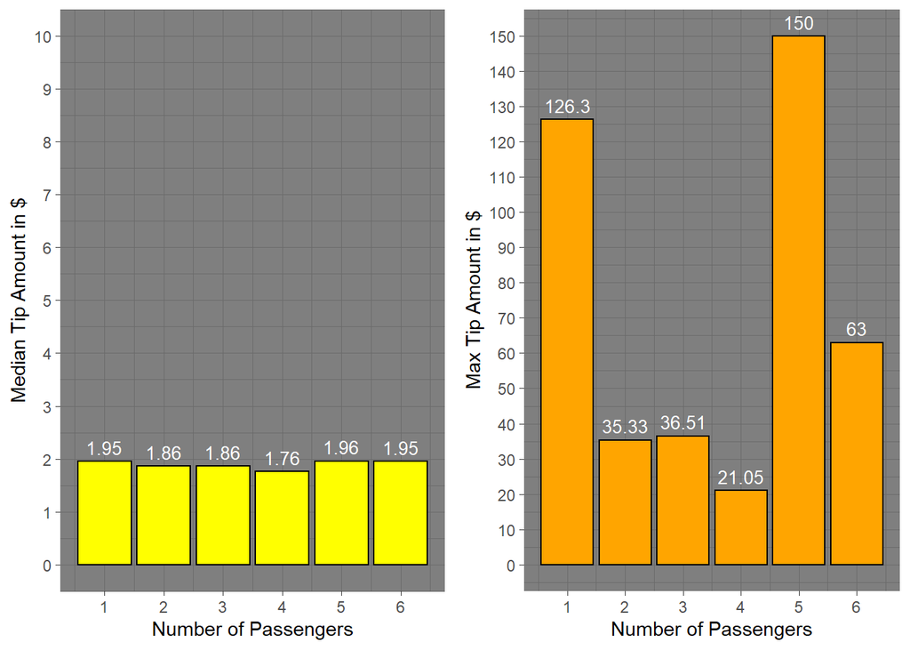

```r
numOfPassengers <- 1:6
medianTipAmount <- c(1.95, 1.86, 1.86, 1.76, 1.96, 1.95)
maxTipAmount <- c(126.3, 35.33, 36.51, 21.05, 150, 63)

yellowtipData <- data.frame(numOfPassengers, medianTipAmount, maxTipAmount)

yellowMedTip <- ggplot(yellowtipData, aes(fill=numOfPassengers, y=medianTipAmount, x = numOfPassengers)) +
    geom_bar(stat="identity",  color = "black", fill = "yellow") + scale_x_continuous("Number of Passengers", breaks = 1:6) + scale_y_continuous("Median Tip Amount in $",seq(0, 10, by=1), limits = c(0,10)) + geom_text(aes(label=medianTipAmount), vjust= -0.5, color="white", position = position_dodge(0.9), size=3.5) + theme_dark()

yellowMaxTip <- ggplot(yellowtipData, aes(fill=numOfPassengers, y=maxTipAmount, x = numOfPassengers)) +
    geom_bar(stat="identity", color = "black", fill = "orange") + scale_x_continuous("Number of Passengers", breaks = 1:6) + scale_y_continuous("Max Tip Amount in $",seq(0, 150, by=10), limits = c(0,150)) + geom_text(aes(label=maxTipAmount), vjust= -0.5, color="white", position = position_dodge(0.9), size=3.5) + theme_dark()

ggarrange(yellowMedTip, yellowMaxTip)
```

Repeat code for green cabs.

```r
greenDataP1 <- filter(greenDataFull, passenger_count == 1)
median(greenDataP1$tip_amount)
```

```
## [1] 0
```

```r
max(greenDataP1$tip_amount)
```

```
## [1] 121
```

```r
greenDataP2 <- filter(greenDataFull, passenger_count == 2)
median(greenDataP2$tip_amount)
```

```
## [1] 0
```

```r
max(greenDataP2$tip_amount)
```

```
## [1] 51.1
```

```r
greenDataP3 <- filter(greenDataFull, passenger_count == 3)
median(greenDataP3$tip_amount)
```

```
## [1] 0
```

```r
max(greenDataP3$tip_amount)
```

```
## [1] 17.42
```

```r
greenDataP4 <- filter(greenDataFull, passenger_count == 4)
median(greenDataP4$tip_amount)
```

```
## [1] 0
```

```r
max(greenDataP4$tip_amount)
```

```
## [1] 19.03
```

```r
greenDataP5 <- filter(greenDataFull, passenger_count == 5)
median(greenDataP5$tip_amount)
```

```
## [1] 0
```

```r
max(greenDataP5$tip_amount)
```

```
## [1] 19.42
```

```r
greenDataP6 <- filter(greenDataFull, passenger_count == 6)
median(greenDataP6$tip_amount)
```

```
## [1] 0
```

```r
max(greenDataP6$tip_amount)
```

```
## [1] 25
```

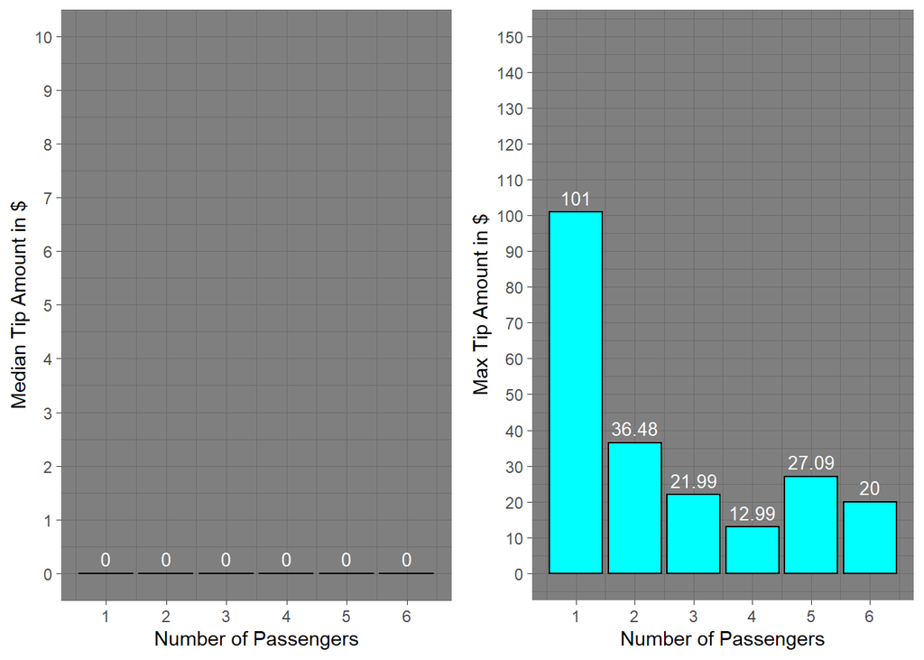

```r
greennumOfPassengers <- 1:6
greenmedianTipAmount <- c(0, 0, 0, 0, 0, 0)
greenmaxTipAmount <- c(101, 36.48, 21.99, 12.99, 27.09, 20)

greentipData <- data.frame(numOfPassengers, greenmedianTipAmount, greenmaxTipAmount)

greenMedTip <- ggplot(greentipData, aes(fill=numOfPassengers, y=greenmedianTipAmount, x = greennumOfPassengers)) +
    geom_bar(stat="identity",  color = "black", fill = "green") + scale_x_continuous("Number of Passengers", breaks = 1:6) + scale_y_continuous("Median Tip Amount in $",seq(0, 10, by=1), limits = c(0,10)) + geom_text(aes(label=greenmedianTipAmount), vjust= -0.5, color="white", position = position_dodge(0.9), size=3.5) + theme_dark()

greenMaxTip <- ggplot(greentipData, aes(fill=numOfPassengers, y=greenmaxTipAmount, x = greennumOfPassengers)) +
    geom_bar(stat="identity", color = "black", fill = "cyan") + scale_x_continuous("Number of Passengers", breaks = 1:6) + scale_y_continuous("Max Tip Amount in $",seq(0, 150, by=10), limits = c(0,150)) + geom_text(aes(label=greenmaxTipAmount), vjust= -0.5, color="white", position = position_dodge(0.9), size=3.5) + theme_dark()

ggarrange(greenMedTip, greenMaxTip)
```

A1. There does not seem to be a relationship between number of passengers and their median and maximum tips. Generally, the yellow cabs receive tips under $2, while the green cabs are unlikely to receive tips at all. This result might be attributed to a little over fourth of the yellow cabs not receiving tips and over half of the green cabs not receiving tips.

Q2. Is cash still the most predominant method of payment in 2019? The Data frame provided by the Taxi and Limousine Commission (TLC) conveniently has the payment method recorded. We will use a bar chart to show which payment method is most dominant.

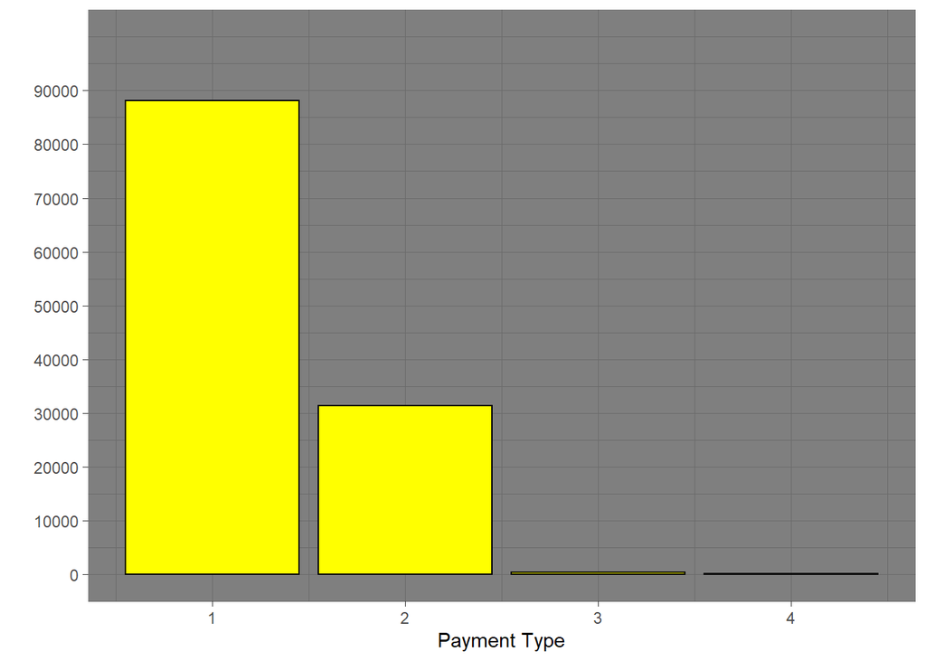

```r
ggplot(yellowDataFull, aes(x= payment_type))+
         geom_bar(stat = "count", color = "black", fill= "yellow" ) + scale_y_continuous("", seq(0, 90000, by=10000), limits = c(0,100000)) + theme_dark() + xlab("Payment Type")
```

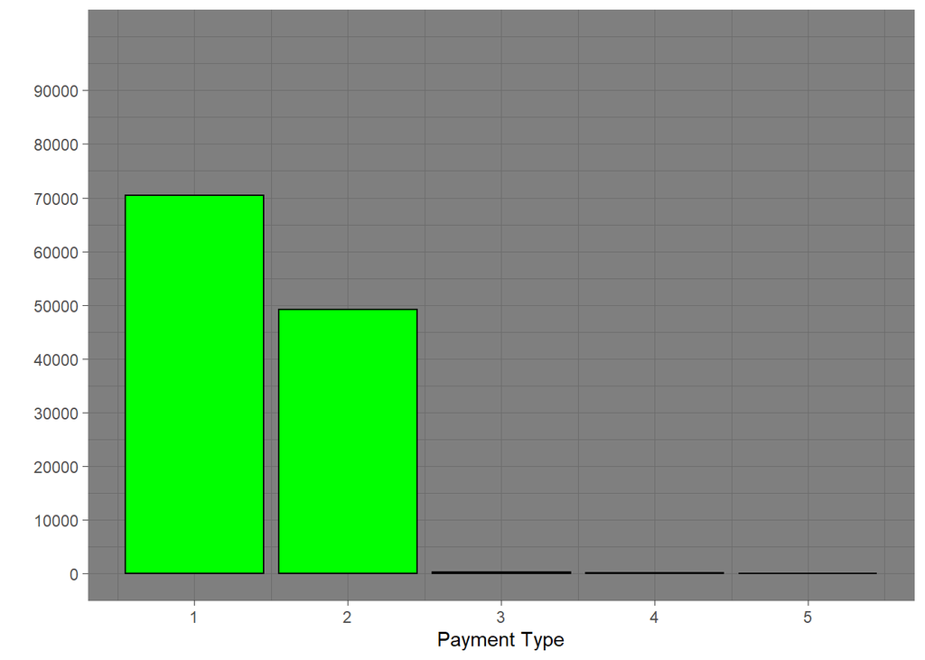

```r
ggplot(greenDataFull, aes(x= payment_type))+
         geom_bar(stat = "count", color = "black", fill= "green" ) + scale_y_continuous("", seq(0, 90000, by=10000), limits = c(0,100000)) + theme_dark() + xlab("Payment Type")
```

A2. Referring to the data dictionary for both;

yellow cab data dictionary: https://www1.nyc.gov/assets/tlc/downloads/pdf/data_dictionary_trip_records_yellow.pdf

green cab data dictionary: https://www1.nyc.gov/assets/tlc/downloads/pdf/data_dictionary_trip_records_green.pdf

1 - Credit Card 2 - Cash 3 - No Charge 4 - Dispute 5 - Unknown

There seems to be less of a disparity, though sizeable, between Cash and Credit payments for green cabs. That said, Cash is no longer king. As in both green and yellow cabs, Credit card payments compromise most of the payments. Trips with No Charges, Disputes, and Unknown are the overwhelming minority, this indicates that they do not happen often or much at all.

Q3. Does the median trip distance increase with number of passengers or do they remain relatively the same? Do groups travel further? How about the maximum trip distances?

```r
yellowDataD1 <- filter(yellowDataFull, passenger_count == 1)
median(yellowDataP1$trip_distance)
```

```
## [1] 1.7
```

```r
max(yellowDataP1$trip_distance)
```

```
## [1] 81.83
```

```r
yellowDataD2 <- filter(yellowDataFull, passenger_count == 2)
median(yellowDataP2$trip_distance)
```

```
## [1] 1.78
```

```r
max(yellowDataP2$trip_distance)
```

```
## [1] 102.2
```

```r
yellowDataD3 <- filter(yellowDataFull, passenger_count == 3)
median(yellowDataP3$trip_distance)
```

```
## [1] 1.74
```

```r
max(yellowDataP3$trip_distance)
```

```
## [1] 40.05
```

```r
yellowDataD4 <- filter(yellowDataFull, passenger_count == 4)
median(yellowDataP4$trip_distance)
```

```
## [1] 1.8
```

```r
max(yellowDataP4$trip_distance)
```

```
## [1] 36.2
```

```r
yellowDataD5 <- filter(yellowDataFull, passenger_count == 5)
median(yellowDataP5$trip_distance)
```

```
## [1] 1.72
```

```r
max(yellowDataP5$trip_distance)
```

```
## [1] 46.09
```

```r
yellowDataD6 <- filter(yellowDataFull, passenger_count == 6)
median(yellowDataP6$trip_distance)
```

```
## [1] 1.72
```

```r
max(yellowDataP6$trip_distance)
```

```
## [1] 43.02
```

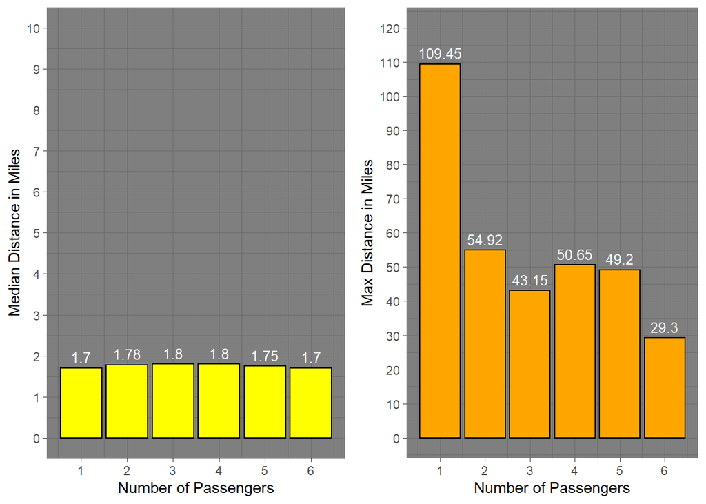

```r
medianTripDist <- c(1.7, 1.78, 1.8, 1.8, 1.75, 1.7 )
maxTripDist <- c(109.45, 54.92, 43.15, 50.65, 49.2, 29.3)

yellowTripData <- data.frame(numOfPassengers, medianTripDist, maxTripDist)

yellowMedTrip <- ggplot(yellowTripData, aes(fill=numOfPassengers, y=medianTripDist, x = numOfPassengers)) +
    geom_bar(stat="identity",  color = "black", fill = "yellow") + scale_x_continuous("Number of Passengers", breaks = 1:6) + scale_y_continuous("Median Distance in Miles",seq(0, 10, by=1), limits = c(0,10)) + geom_text(aes(label=medianTripDist), vjust= -0.5, color="white", position = position_dodge(0.9), size=3.5) + theme_dark()

yellowMaxTrip <- ggplot(yellowTripData, aes(fill=numOfPassengers, y=maxTripDist, x = numOfPassengers)) +
    geom_bar(stat="identity", color = "black", fill = "orange") + scale_x_continuous("Number of Passengers", breaks = 1:6) + scale_y_continuous("Max Distance in Miles",seq(0, 120, by=10), limits = c(0,120)) + geom_text(aes(label=maxTripDist), vjust= -0.5, color="white", position = position_dodge(0.9), size=3.5) + theme_dark()

ggarrange(yellowMedTrip, yellowMaxTrip)
```

```r
greenDataD1 <- filter(greenDataFull, passenger_count == 1)
median(greenDataP1$trip_distance)
```

```
## [1] 1.99
```

```r
max(greenDataP1$trip_distance)
```

```
## [1] 56.8
```

```r
greenDataD2 <- filter(greenDataFull, passenger_count == 2)
median(greenDataP2$trip_distance)
```

```
## [1] 2.08
```

```r
max(greenDataP2$trip_distance)
```

```
## [1] 50.51
```

```r
greenDataD3 <- filter(greenDataFull, passenger_count == 3)
median(greenDataP3$trip_distance)
```

```
## [1] 2.02
```

```r
max(greenDataP3$trip_distance)
```

```
## [1] 99.62
```

```r
greenDataD4 <- filter(greenDataFull, passenger_count == 4)
median(greenDataP4$trip_distance)
```

```
## [1] 1.955
```

```r
max(greenDataP4$trip_distance)
```

```
## [1] 25.91
```

```r
greenDataD5 <- filter(greenDataFull, passenger_count == 5)
median(greenDataP5$trip_distance)
```

```
## [1] 1.88
```

```r
max(greenDataP5$trip_distance)
```

```
## [1] 28.52
```

```r
greenDataD6 <- filter(greenDataFull, passenger_count == 6)
median(greenDataP6$trip_distance)
```

```
## [1] 1.86
```

```r
max(greenDataP6$trip_distance)
```

```
## [1] 28.15
```

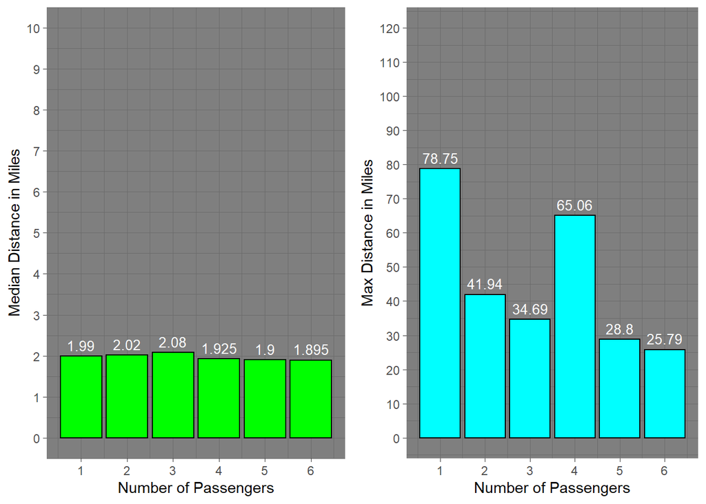

```r
greenmedianTripDist <- c(1.99, 2.02, 2.08, 1.925, 1.9, 1.895)
greenmaxTripDist <- c(78.75 ,41.94, 34.69, 65.06, 28.8, 25.79)

greenTripData <- data.frame(numOfPassengers, greenmedianTripDist, greenmaxTripDist)

greenMedTrip <- ggplot(greenTripData, aes(fill=numOfPassengers, y=greenmedianTripDist, x = numOfPassengers)) +
    geom_bar(stat="identity",  color = "black", fill = "green") + scale_x_continuous("Number of Passengers", breaks = 1:6) + scale_y_continuous("Median Distance in Miles",seq(0, 10, by=1), limits = c(0,10)) + geom_text(aes(label=greenmedianTripDist), vjust= -0.5, color="white", position = position_dodge(0.9), size=3.5) + theme_dark()

greenMaxTrip <- ggplot(greenTripData, aes(fill=numOfPassengers, y=greenmaxTripDist, x = numOfPassengers)) +
    geom_bar(stat="identity", color = "black", fill = "cyan") + scale_x_continuous("Number of Passengers", breaks = 1:6) + scale_y_continuous("Max Distance in Miles",seq(0, 120, by=10), limits = c(0,120)) + geom_text(aes(label=greenmaxTripDist), vjust= -0.5, color="white", position = position_dodge(0.9), size=3.5) + theme_dark()

ggarrange(greenMedTrip, greenMaxTrip)
```

A3. The data shows that there is little almost no difference between one, two, three, four, five, and six passenger trips in terms of median trip distance. However, in terms of max trip distance one passenger trips tend to be around triple the distance versus six passenger trips for green cabs, and almost quadruple for yellow cabs. The decrease from one to six passenger rides also do not seem to follow a linear decrease, but have a slight increase in four passenger trips before decreasing again.

Q4. Which days are the busiest in the week? Is the disparity very significant or is it more or less the same?

```r
yellowDataFull <- rbind(yellowData01, yellowData02, yellowData03, yellowData04, yellowData05, yellowData06, yellowData07, yellowData08, yellowData09, yellowData10, yellowData11, yellowData12)

yellowDataFull <- yellowDataFull%>% separate(tpep_pickup_datetime, c("pickup_date", "pickup_time"), " ")
yellowDataFull <- yellowDataFull%>% separate(tpep_dropoff_datetime, c("dropoff_date", "dropoff_time"), " ")

yellowDataFull$weekday <- weekdays(as.Date(yellowDataFull$pickup_date))

yellowDataFull$weekday <- factor(yellowDataFull$weekday, levels= c("Sunday", "Monday",
    "Tuesday", "Wednesday", "Thursday", "Friday", "Saturday"))

yellowWeek <- ggplot(yellowDataFull, aes(y = 1, x = weekday)) +
    geom_bar(stat="identity", fill = "yellow") + scale_y_continuous("Number of Trips",seq(0, 20000, by=2000), limits = c(0,20000)) + theme(axis.text.x = element_text(angle = 45, hjust = 1)) + xlab("Weekday")
```

```r
greenDataFull <- rbind(greenData01, greenData02, greenData03, greenData04, greenData05, greenData06, greenData07, greenData08, greenData09, greenData10, greenData11, greenData12)

greenDataFull <- greenDataFull%>% separate(lpep_pickup_datetime, c("pickup_date", "pickup_time"), " ")
greenDataFull <- greenDataFull%>% separate(lpep_dropoff_datetime, c("dropoff_date", "dropoff_time"), " ")

greenDataFull$weekday <- weekdays(as.Date(greenDataFull$pickup_date))

greenDataFull$weekday <- factor(greenDataFull$weekday, levels= c("Sunday", "Monday",
    "Tuesday", "Wednesday", "Thursday", "Friday", "Saturday"))

greenWeek <- ggplot(greenDataFull, aes(y = 1, x = weekday)) +
    geom_bar(stat="identity", fill = "green") + scale_y_continuous("Number of Trips",seq(0, 20000, by=2000), limits = c(0,20000)) + theme(axis.text.x = element_text(angle = 45, hjust = 1)) + xlab("Weekday")
```

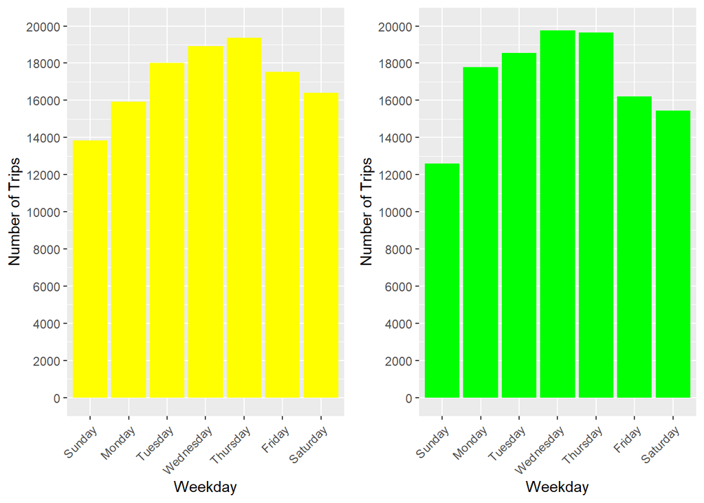

```r
ggarrange(yellowWeek, greenWeek)
```

A4. The busiest days of the week are Wednesdays and Thursdays. Yellow cabs experience a relatively steady increase from Sunday up to Wednesday, a plateau from Wednesday to Thursday, and a decline from Thursday to Saturday. On the other hand, green cabs experience a significant spike from Sunday to Monday, a steady increase from Tuesday to Thursday, and a rapid decline that into Saturday. While this graph does not show the actual number of trips (in the millions), it still shows the trend of trips made in a week.

Q5. Which hours of the day are the busiest? Do they coincide with NYC’s Rush Hours of 7 AM to 9 AM and 4 PM to 6 PM?

```r
yellowDataFull <- rbind(yellowData01, yellowData02, yellowData03, yellowData04, yellowData05, yellowData06, yellowData07, yellowData08, yellowData09, yellowData10, yellowData11, yellowData12)

yellowDataFull <- yellowDataFull %>% mutate(hour_trip_start = factor(hour(tpep_pickup_datetime)))

yellowDataFull <- yellowDataFull%>% separate(tpep_pickup_datetime, c("pickup_date", "pickup_time"), " ")
yellowDataFull <- yellowDataFull%>% separate(tpep_dropoff_datetime, c("dropoff_date", "dropoff_time"), " ")

yellowDataFull$weekday <- weekdays(as.Date(yellowDataFull$pickup_date))

yellowDataFull$weekday <- factor(yellowDataFull$weekday, levels= c("Sunday", "Monday",
    "Tuesday", "Wednesday", "Thursday", "Friday", "Saturday"))

yellowDataDay <- filter(yellowDataFull, weekday != "Sunday", weekday != "Saturday")

yellowDataEnd <- filter(yellowDataFull, weekday != "Monday", weekday != "Tuesday",  weekday != "Wednesday", weekday != "Thursday",  weekday != "Friday")

yellowHourDay <- ggplot(yellowDataDay, aes(x=hour_trip_start, y=1)) + geom_bar(stat="identity", fill = "yellow") + scale_y_continuous("Number of Trips",seq(0, 10000, by=1000), limits = c(0,10000)) + theme_dark() + xlab("Hour Trip Started")

yellowHourDay <- yellowHourDay + theme(axis.text.x = element_text(size = 7))

yellowHourEnd <- ggplot(yellowDataEnd, aes(x=hour_trip_start, y=1)) + geom_bar(stat="identity", fill = "yellow") + scale_y_continuous("Number of Trips",seq(0, 5000, by=500), limits = c(0,5000)) + theme_dark() + xlab("")

yellowHourEnd <- yellowHourEnd + theme(axis.text.x = element_text(size = 7))
```

```r
greenDataFull <- rbind(greenData01, greenData02, greenData03, greenData04, greenData05, greenData06, greenData07, greenData08, greenData09, greenData10, greenData11, greenData12)

greenDataFull <- greenDataFull %>% mutate(hour_trip_start = factor(hour(lpep_pickup_datetime)))

greenDataFull <- greenDataFull%>% separate(lpep_pickup_datetime, c("pickup_date", "pickup_time"), " ")
greenDataFull <- greenDataFull%>% separate(lpep_dropoff_datetime, c("dropoff_date", "dropoff_time"), " ")

greenDataFull$weekday <- weekdays(as.Date(greenDataFull$pickup_date))

greenDataFull$weekday <- factor(greenDataFull$weekday, levels= c("Sunday", "Monday",
    "Tuesday", "Wednesday", "Thursday", "Friday", "Saturday"))

greenDataDay <- filter(greenDataFull, weekday != "Sunday", weekday != "Saturday")

greenDataEnd <- filter(greenDataFull, weekday != "Monday", weekday != "Tuesday",  weekday != "Wednesday", weekday != "Thursday",  weekday != "Friday")

greenHourDay <- ggplot(greenDataDay, aes(x=hour_trip_start, y=1)) + geom_bar(stat="identity", fill = "green") + scale_y_continuous("Number of Trips",seq(0, 10000, by=1000), limits = c(0,10000)) + theme_dark() + xlab("")

greenHourDay <- greenHourDay + theme(axis.text.x = element_text(size = 7))

greenHourEnd <- ggplot(greenDataEnd, aes(x=hour_trip_start, y=1)) + geom_bar(stat="identity", fill = "green") + scale_y_continuous("Number of Trips",seq(0, 5000, by=500), limits = c(0,5000)) + theme_dark() + xlab("")

greenHourEnd <- greenHourEnd + theme(axis.text.x = element_text(size = 7))
```

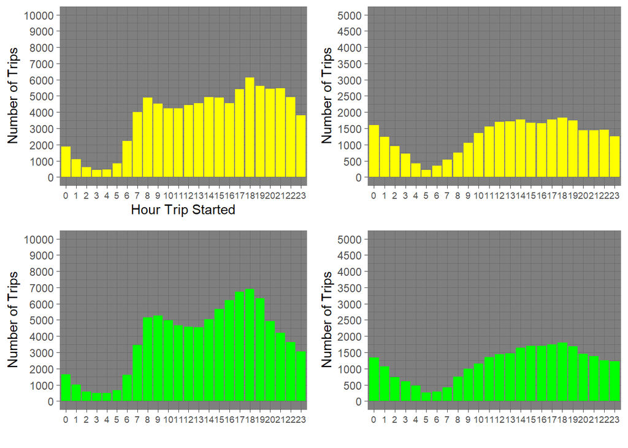

```r
ggarrange(yellowHourDay, yellowHourEnd, greenHourDay, greenHourEnd,
          ncol = 2, nrow = 2)
```

A5. Both follow a similar trend. A rapid rise in number of trips starting from 6 AM and eventually plateauing at 9 AM with minor fluctuations until 12 PM. The usage gets a gradual increase from 12 PM until it peaks at around 6 PM for both green and yellow cabs. Again, they follow a similar trend of gradually tapering off in the later hours of the night.

Q6. What is the relationship between trip distance and tip amount? Is it a linear increase, decrease, or does it stay more or less the same?

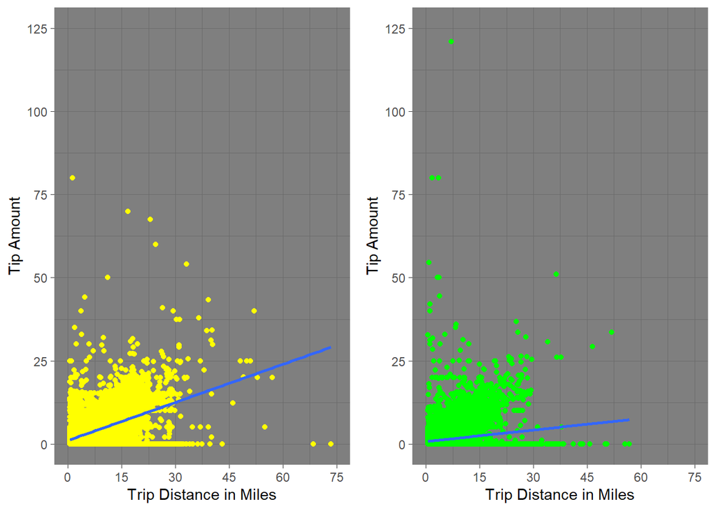

```r
yellowTipTrip <- ggplot(yellowDataFull, aes(x = trip_distance, y = tip_amount)) + geom_point(color = "yellow", stat = "identity") + scale_y_continuous("Tip Amount", seq(0, 125, by = 25), limits = c(0, 125)) + scale_x_continuous("Trip Distance in Miles",  seq(0, 75, by = 15), limits = c(0, 75)) + theme_dark() + stat_smooth(method="lm", se=FALSE)
greenTipTrip <- ggplot(greenDataFull, aes(x = trip_distance, y = tip_amount)) + geom_point(color = "green", stat = "identity") + scale_y_continuous("Tip Amount", seq(0, 125, by = 25), limits = c(0, 125)) + scale_x_continuous("Trip Distance in Miles", seq(0, 75, by = 15), limits = c(0, 75)) + theme_dark() + stat_smooth(method="lm", se=FALSE)

ggarrange(yellowTipTrip, greenTipTrip,
          ncol = 2, nrow = 1)
```

A6. The graph shows that there are many people who do not tip at all, even on trips close to 60 miles. The blue line indicates the trend for the relationship between trip distance and tip amount. This indicates a linear increase in tip amount as trip distance increases. To answer the question, yes there is a positive correlation between the two variables and no tip amount does not remain constant nor does it decrease as trip distance increases.